# Bayesian Cognitive Modelling — Chapter 1

From a generative model to posterior inference and prediction

# 1 The modelling problem

A person answers **10 questions** and gets **9 correct**.

The observed data are therefore:

$$k=9, \qquad n=10$$

The quantity we want to learn about is not directly observed. We call it:

$$\theta = \text{underlying probability of answering a comparable question
correctly}$$

This gives us the first distinction that matters for the whole chapter:

```
OBSERVED DATA:       9 correct out of 10
UNKNOWN PARAMETER:   theta
```

```r
# DATA: total number of observed questions.
n <- 10

# DATA: number of observed correct responses.
k <- 9

# DESCRIPTIVE SUMMARY OF THE DATA.
# This is what happened in this particular sample.
observed_proportion <- k / n

observed_proportion
```

```
## [1] 0.9
```

The result is 0.90, but this does **not** mean that $\theta$ is known to be exactly 0.90.

A finite sample fluctuates. A person with $\theta=.80$ can sometimes obtain 9/10; a person with $\theta=.70$ can also sometimes obtain 9/10. Statistical modelling is needed because the observed sample and the underlying parameter are not the same thing.

# 2 Start with the generative model

Before trying to infer $\theta$, ask what the model says would happen **if $\theta$ were known**.

The chapter assumes a binomial sampling model:

$$K \sim \text{Binomial}(n,\theta)$$

This means that once $n$ and $\theta$ are specified, the model gives probabilities for every possible number of correct responses.

For this model to make sense, we are assuming that:

1. each response is coded as correct/incorrect;
2. the same $\theta$ applies to all 10 questions;
3. responses are conditionally independent given $\theta$;
4. the total number correct is the relevant outcome.

We can see what different values of $\theta$ predict.

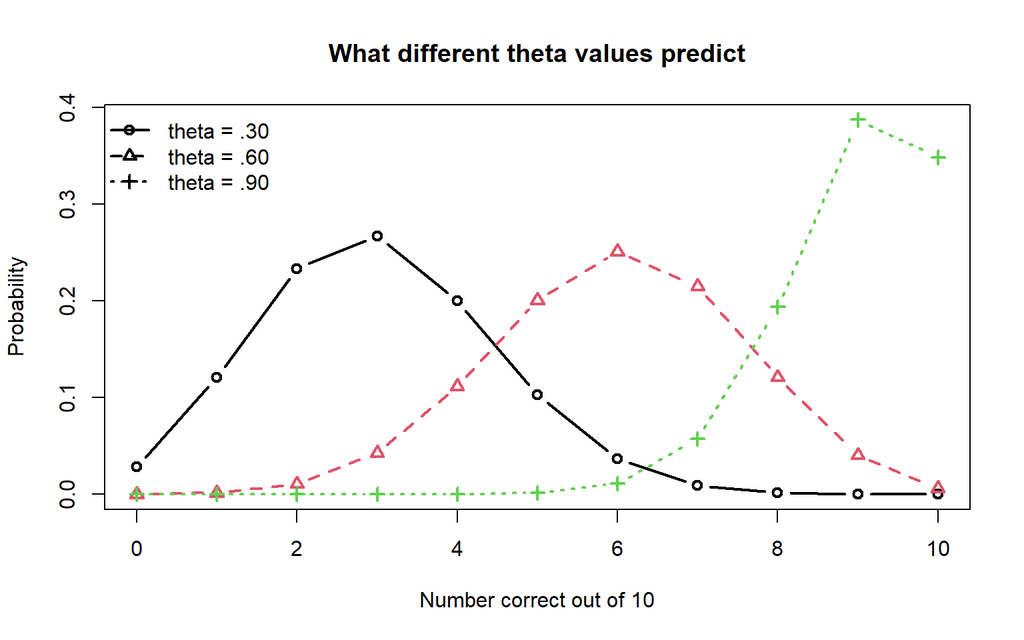

```r
# With 10 binary questions, the observable score can be 0, 1, ..., 10.
possible_k <- 0:n

# dbinom() is used because our DATA-GENERATING MODEL is binomial.
#
# For a FIXED theta, dbinom() calculates:
#
#   P(K = x | n, theta)
#
# Here x = possible_k, so we obtain probabilities for EVERY possible observed score.

# What data would the model predict if theta were .30?
p_theta_30 <- dbinom(
  x = possible_k,  # every possible observable score: 0,...,10
  size = n,        # number of questions
  prob = 0.30      # assume theta = .30
)

# Same data-generating model, but assume theta = .60.
p_theta_60 <- dbinom(
  x = possible_k,
  size = n,
  prob = 0.60
)

# Same data-generating model, but assume theta = .90.
p_theta_90 <- dbinom(
  x = possible_k,
  size = n,
  prob = 0.90
)

# Plot the three model predictions.
# The plotting commands below do not alter the model; they only display its predictions.
matplot(
  possible_k,
  cbind(p_theta_30, p_theta_60, p_theta_90),
  type = "b",
  pch = c(1, 2, 3),
  lty = c(1, 2, 3),
  lwd = 2,
  xlab = "Number correct out of 10",
  ylab = "Probability",
  main = "What different theta values predict"
)

legend(
  "topleft",
  legend = c("theta = .30", "theta = .60", "theta = .90"),
  lty = c(1, 2, 3),
  pch = c(1, 2, 3),
  lwd = 2,
  bty = "n"
)
```

The interpretation is entirely generative:

> Assume a value of $\theta$, then ask what observable data that value would tend to generate.

When $\theta=.30$, scores around 3/10 are common and 9/10 is unusual. When $\theta=.90$, scores around 9/10 are common.

This is why the data can teach us about the parameter: **different parameter values make different predictions about observable behaviour**.

# 3 From the generative model to the likelihood

Now reverse the question.

We no longer ask:

> If $\theta$ were .30 or .90, what data would I expect?

We already observed the data: **9 correct out of 10**.

Now ask:

> Which candidate values of $\theta$ make the observed 9/10 more or less plausible?

That is the likelihood.

First create a fine grid of candidate parameter values so we can draw the likelihood as a function of $\theta$.

```r
# theta is a probability, so its parameter space is 0 to 1.
#
# This grid is only a numerical device for evaluating and plotting a continuous function.
# It does NOT mean the model believes theta can take only these 1000 values.
theta <- seq(
  from = 0.001,
  to = 0.999,
  length.out = 1000
)
```

Now use the **same binomial model**, but change what is fixed and what varies.

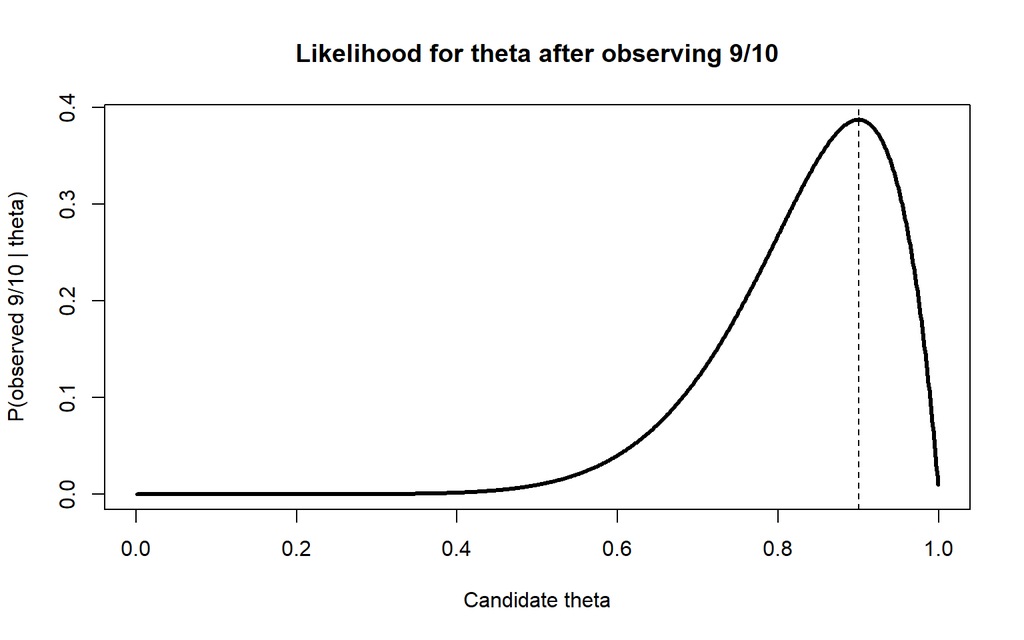

```r
# LIKELIHOOD.
#
# In the generative section:
#   - theta was fixed;
#   - possible DATA values varied.
#
# Here:
#   - the observed DATA are fixed at k = 9, n = 10;
#   - candidate theta values vary.
#
# dbinom() therefore evaluates:
#
#   P(K = 9 | n = 10, theta)
#
# for every candidate theta in the grid.
likelihood <- dbinom(
  x = k,          # FIX the observed data at 9 successes
  size = n,       # FIX the observed number of trials at 10
  prob = theta    # VARY the unknown parameter theta
)

# Each element has a precise interpretation:
# likelihood[i] = P(observed 9/10 | theta = theta[i]).
#
# This is p(DATA | theta).
# It is NOT p(theta | DATA).

plot(
  theta,
  likelihood,
  type = "l",
  lwd = 3,
  xlab = "Candidate theta",
  ylab = "P(observed 9/10 | theta)",
  main = "Likelihood for theta after observing 9/10"
)

# The likelihood is maximized at k/n = .90 in this example.
abline(v = observed_proportion, lty = 2)
```

The height at $\theta=.80$, for example, answers:

$$P(K=9\mid n=10,\theta=.80)$$

It does **not** answer the probability that $\theta=.80$ is true. To move from the probability of the data given a parameter to uncertainty about the parameter given the data, Bayesian inference adds a prior.

# 4 Add prior uncertainty about theta

Before using the current 9/10 result, the chapter represents uncertainty about $\theta$ with a uniform prior from 0 to 1.

A uniform distribution on this interval is equivalent to:

$$\theta \sim Beta(1,1)$$

The Beta family is useful here because it is defined on the same 0–1 interval as a probability parameter.

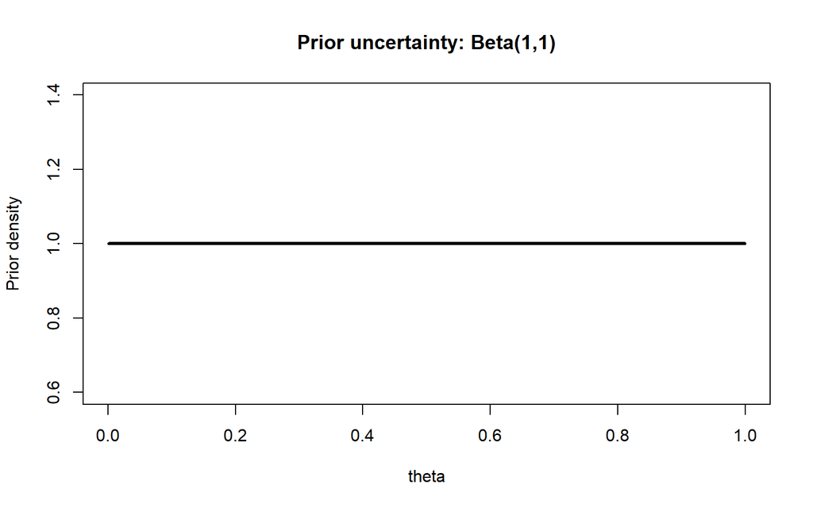

```r
# PRIOR.
#
# dbeta() evaluates the DENSITY of a Beta distribution at candidate theta values.
# With shape1=1 and shape2=1, Beta(1,1) is flat over 0 to 1.
prior <- dbeta(
  x = theta,      # candidate theta values
  shape1 = 1,     # alpha of the Beta prior
  shape2 = 1      # beta of the Beta prior
)

# Important: dbeta() returns DENSITY HEIGHTS.
# For a continuous parameter, probability corresponds to AREA over an interval,
# not to the probability of one exact point.

plot(
  theta,
  prior,
  type = "l",
  lwd = 3,
  xlab = "theta",
  ylab = "Prior density",
  main = "Prior uncertainty: Beta(1,1)"
)
```

At this point the model has two distinct parts:

$$\theta \sim Beta(1,1)$$

and

$$K \sim Binomial(n,\theta)$$

The prior describes uncertainty about the hidden parameter. The binomial likelihood describes how that hidden parameter generates observable data.

# 5 Bayes’ rule produces the posterior

Bayes’ rule combines the prior and likelihood:

$$p(\theta\mid D)
\propto
p(D\mid\theta)p(\theta)$$

In words:

> **posterior support = prior support × support from the observed data**

For this example, we can first show the multiplication numerically.

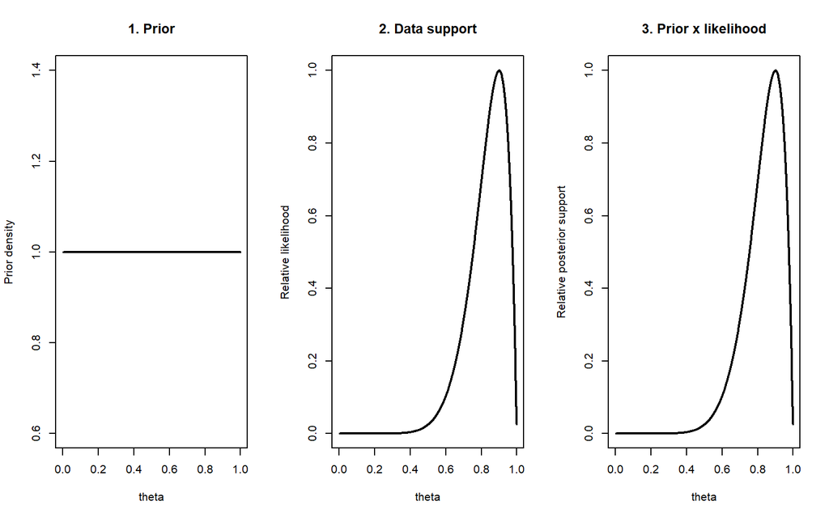

```r
# BAYESIAN UPDATE: the unnormalized posterior kernel.
#
# At every candidate theta, multiply:
#   likelihood of the observed data
# by
#   prior density at that theta.
posterior_kernel <- likelihood * prior

# We use the kernel only to demonstrate the SHAPE implied by Bayes' rule.
# The exact normalized continuous posterior is available analytically below.

# Relative likelihood is useful for plotting because a likelihood is not itself
# a probability distribution over theta. Dividing by its maximum leaves its shape unchanged.
relative_likelihood <- likelihood / max(likelihood)

# Do the same with the posterior kernel purely to compare shapes visually.
relative_posterior_kernel <- posterior_kernel / max(posterior_kernel)

# Show the three stages in separate panels so we do not pretend they share the same units.
par(mfrow = c(1, 3))

plot(
  theta,
  prior,
  type = "l",
  lwd = 2,
  xlab = "theta",
  ylab = "Prior density",
  main = "1. Prior"
)

plot(
  theta,
  relative_likelihood,
  type = "l",
  lwd = 2,
  xlab = "theta",
  ylab = "Relative likelihood",
  main = "2. Data support"
)

plot(
  theta,
  relative_posterior_kernel,
  type = "l",
  lwd = 2,
  xlab = "theta",
  ylab = "Relative posterior support",
  main = "3. Prior x likelihood"
)
```

```r
par(mfrow = c(1, 1))
```

The flat prior contributes no preference for one part of the parameter space over another, so the posterior shape here is driven mainly by the likelihood.

The important conceptual transition is:

```
LIKELIHOOD:  Which theta values predict the observed data well?

POSTERIOR:   After combining those data with the prior,
             which theta values remain plausible?
```

# 6 The exact Beta-Binomial posterior

This example is especially convenient because a Beta prior combined with a binomial likelihood gives a Beta posterior. This is called **conjugacy**.

If:

$$\theta \sim Beta(\alpha,\beta)$$

and the data contain $k$ successes and $n-k$ failures, then:

$$\theta\mid D \sim Beta(\alpha+k,\beta+n-k)$$

For the chapter’s example:

```r
# PRIOR PARAMETERS for Beta(1,1).
alpha_prior <- 1
beta_prior <- 1

# DATA expressed as successes and failures.
successes <- k
failures <- n - k

# CONJUGATE UPDATE.
# Successes update alpha; failures update beta.
alpha_posterior <- alpha_prior + successes
beta_posterior <- beta_prior + failures

# Display the resulting posterior parameters together.
c(
  alpha_posterior = alpha_posterior,
  beta_posterior = beta_posterior
)
```

```
## alpha_posterior  beta_posterior
##              10               2
```

So:

$$\theta\mid D \sim Beta(10,2)$$

Now `dbeta()` has a different role from the prior section because we supply the **posterior** shape parameters.

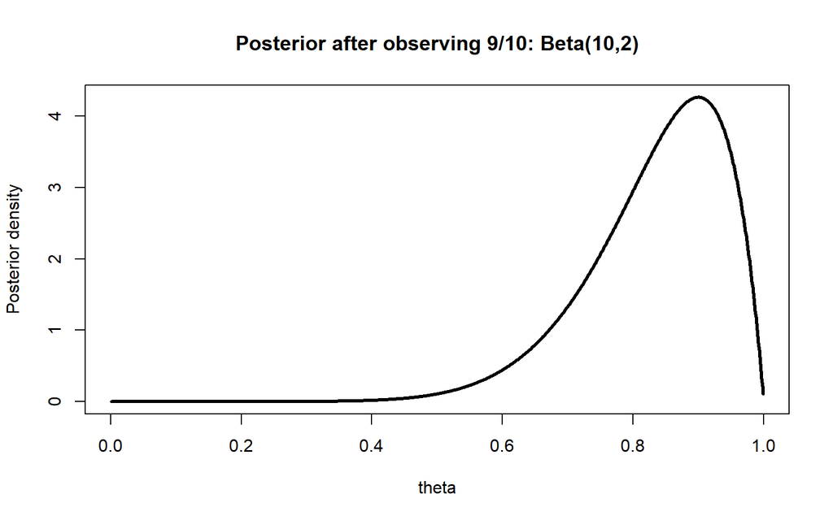

```r
# EXACT POSTERIOR DENSITY.
#
# dbeta() is still just evaluating a Beta density.
# What makes this the POSTERIOR is that the parameters are now 10 and 2,
# obtained after updating the prior with the observed data.
posterior <- dbeta(
  x = theta,
  shape1 = alpha_posterior,
  shape2 = beta_posterior
)

plot(
  theta,
  posterior,
  type = "l",
  lwd = 3,
  xlab = "theta",
  ylab = "Posterior density",
  main = "Posterior after observing 9/10: Beta(10,2)"
)
```

The posterior is concentrated toward high values of $\theta$, but it is not a single point. Its width represents the uncertainty that remains after seeing only ten responses.

# 7 Why 9/10 does not imply theta = .90 exactly

The likelihood itself shows why uncertainty remains.

```r
# Hold the DATA fixed at 9/10 and inspect the likelihood at selected theta values.
selected_theta <- c(.50, .60, .70, .80, .90)

selected_likelihood <- dbinom(
  x = k,
  size = n,
  prob = selected_theta
)

# Put candidate theta and its likelihood side by side for easy reading.
data.frame(
  theta = selected_theta,
  likelihood_of_9_out_of_10 = selected_likelihood
)
```

```
##   theta likelihood_of_9_out_of_10
## 1   0.5               0.009765625
## 2   0.6               0.040310784
## 3   0.7               0.121060821
## 4   0.8               0.268435456
## 5   0.9               0.387420489
```

Values below .90 can still generate 9/10 with non-zero probability. The posterior therefore represents a **range of plausible values** rather than certainty at .90.

# 8 Summarize the posterior

The full posterior distribution is the primary result. Numerical summaries compress different aspects of it.

## 8.1 Posterior mean and mode

```r
# POSTERIOR MEAN.
# For Beta(alpha,beta), the mean is alpha/(alpha+beta).
posterior_mean <- alpha_posterior /
  (alpha_posterior + beta_posterior)

# POSTERIOR MODE.
# For alpha>1 and beta>1, this is the location of maximum posterior density.
posterior_mode <- (alpha_posterior - 1) /
  (alpha_posterior + beta_posterior - 2)

c(
  posterior_mean = posterior_mean,
  posterior_mode = posterior_mode
)
```

```
## posterior_mean posterior_mode
##      0.8333333      0.9000000
```

The mode is .90, but the mean is about .833 because the posterior is asymmetric. This is another reminder that a posterior cannot be fully described by a single “best” number.

## 8.2 95% credible interval

A 95% credible interval asks for the values of $\theta$ delimiting the central 95% of posterior probability.

For a known Beta posterior, `qbeta()` returns the required **quantiles**.

```r
# qbeta() answers the inverse cumulative question:
# "At what theta has the Beta distribution accumulated probability p?"
#
# p=.025 gives the lower 2.5% boundary.
# p=.975 gives the upper 97.5% boundary.
credible_interval <- qbeta(
  p = c(0.025, 0.975),
  shape1 = alpha_posterior,
  shape2 = beta_posterior
)

credible_interval
```

```
## [1] 0.5872201 0.9771688
```

Under this model and prior, 95% of posterior probability for $\theta$ lies between those two values.

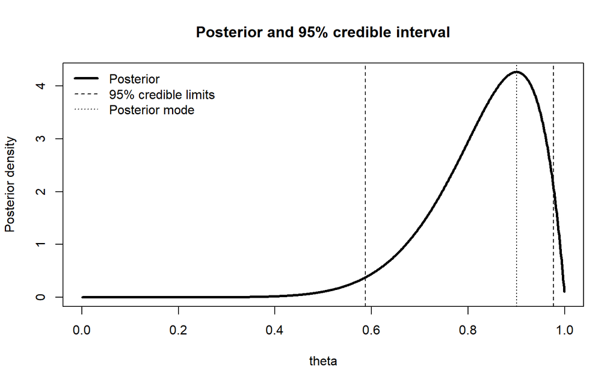

```r
# Extract the two limits only to add them to the posterior plot.
lower <- credible_interval[1]
upper <- credible_interval[2]

plot(
  theta,
  posterior,
  type = "l",
  lwd = 3,
  xlab = "theta",
  ylab = "Posterior density",
  main = "Posterior and 95% credible interval"
)

abline(v = c(lower, upper), lty = 2)
abline(v = posterior_mode, lty = 3)

legend(
  "topleft",
  legend = c("Posterior", "95% credible limits", "Posterior mode"),
  lty = c(1, 2, 3),
  lwd = c(3, 1, 1),
  bty = "n"
)
```

# 9 More data reduce posterior uncertainty

Compare three datasets with exactly the same observed success rate:

```
9 / 10
90 / 100
900 / 1000
```

All equal .90, but they do not carry the same amount of information.

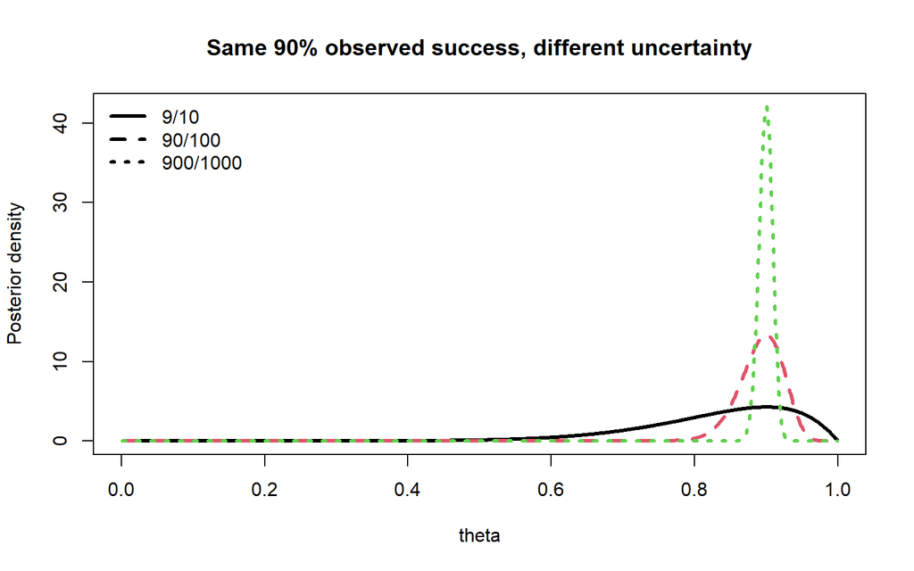

```r
# All three analyses use the SAME Beta(1,1) prior.
# Only the amount of observed data changes.

# 9 successes + 1 failure -> Beta(10,2)
post_10 <- dbeta(theta, 1 + 9, 1 + 1)

# 90 successes + 10 failures -> Beta(91,11)
post_100 <- dbeta(theta, 1 + 90, 1 + 10)

# 900 successes + 100 failures -> Beta(901,101)
post_1000 <- dbeta(theta, 1 + 900, 1 + 100)

matplot(
  theta,
  cbind(post_10, post_100, post_1000),
  type = "l",
  lty = c(1, 2, 3),
  lwd = 3,
  xlab = "theta",
  ylab = "Posterior density",
  main = "Same 90% observed success, different uncertainty"
)

legend(
  "topleft",
  legend = c("9/10", "90/100", "900/1000"),
  lty = c(1, 2, 3),
  lwd = 3,
  bty = "n"
)
```

The centers are similar, but the posterior becomes narrower as the amount of evidence increases.

> **Same point estimate does not mean same uncertainty.**

# 10 Prior sensitivity

The chapter uses a flat Beta(1,1) prior. To understand what the prior contributes, compare that prior with two illustrative alternatives.

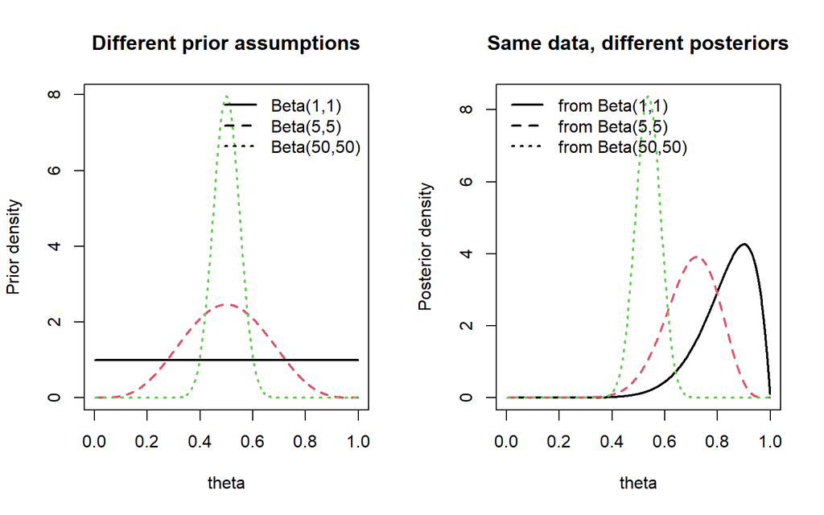

```r
# Three different PRIOR assumptions.
prior_A <- dbeta(theta, 1, 1)    # flat
prior_B <- dbeta(theta, 5, 5)    # moderate concentration near .50
prior_C <- dbeta(theta, 50, 50)  # strong concentration near .50

# Update every prior with exactly the SAME observed data: 9 successes, 1 failure.
post_A <- dbeta(theta, 1 + 9, 1 + 1)
post_B <- dbeta(theta, 5 + 9, 5 + 1)
post_C <- dbeta(theta, 50 + 9, 50 + 1)

par(mfrow = c(1, 2))

matplot(
  theta,
  cbind(prior_A, prior_B, prior_C),
  type = "l",
  lty = c(1, 2, 3),
  lwd = 2,
  xlab = "theta",
  ylab = "Prior density",
  main = "Different prior assumptions"
)
legend(
  "topright",
  legend = c("Beta(1,1)", "Beta(5,5)", "Beta(50,50)"),
  lty = c(1, 2, 3),
  lwd = 2,
  bty = "n"
)

matplot(
  theta,
  cbind(post_A, post_B, post_C),
  type = "l",
  lty = c(1, 2, 3),
  lwd = 2,
  xlab = "theta",
  ylab = "Posterior density",
  main = "Same data, different posteriors"
)
legend(
  "topleft",
  legend = c("from Beta(1,1)", "from Beta(5,5)", "from Beta(50,50)"),
  lty = c(1, 2, 3),
  lwd = 2,
  bty = "n"
)
```

```r
par(mfrow = c(1, 1))
```

The same data can yield different posteriors when the prior information differs. With little data, a concentrated prior can matter substantially; with abundant consistent data, the likelihood increasingly dominates.

# 11 Posterior prediction

The posterior answers:

> What values of $\theta$ are plausible after observing 9/10?

Prediction asks a different question:

> What should we expect on **five new questions**?

Bayesian prediction carries the uncertainty about $\theta$ into the prediction.

The logic is:

```
posterior uncertainty about theta
              ↓
draw a plausible theta
              ↓
generate new data conditional on that theta
```

We can implement that logic by simulation.

```r
# Number of Monte Carlo replications.
Nsim <- 100000

# STEP 1: draw plausible PARAMETER values from the posterior.
#
# rbeta() differs from dbeta():
#   dbeta() evaluates a density;
#   rbeta() generates random draws FROM that distribution.
#
# Each element of theta_draws is one plausible value of the SAME unknown theta.
theta_draws <- rbeta(
  n = Nsim,
  shape1 = alpha_posterior,
  shape2 = beta_posterior
)

# STEP 2: for each sampled theta, simulate one NEW 5-question test.
#
# rbinom() differs from dbinom():
#   dbinom() calculates probabilities;
#   rbinom() actually generates binomial outcomes.
#
# These are FUTURE DATA, not parameter draws.
future_scores <- rbinom(
  n = Nsim,
  size = 5,
  prob = theta_draws
)

# Count how often each possible future score 0,...,5 occurred.
future_counts <- table(
  factor(future_scores, levels = 0:5)
)

# Turn simulation frequencies into approximate predictive probabilities.
posterior_predictive <- future_counts / sum(future_counts)

posterior_predictive
```

```
##
##       0       1       2       3       4       5
## 0.00133 0.01154 0.05065 0.14997 0.32726 0.45925
```

The resulting distribution is about **future observable scores**, not about $\theta$.

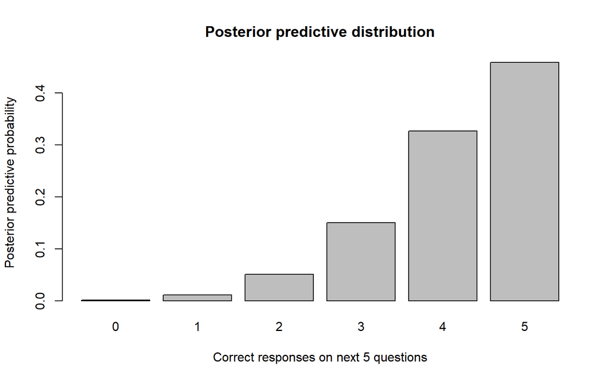

```r
barplot(
  posterior_predictive,
  names.arg = 0:5,
  xlab = "Correct responses on next 5 questions",
  ylab = "Posterior predictive probability",
  main = "Posterior predictive distribution"
)
```

# 12 Prediction with and without parameter uncertainty

A simpler plug-in approach would pretend that $\theta$ is known exactly and set it to the maximum-likelihood estimate .90.

That gives:

$$p(K_{new}\mid\theta=.90)$$

rather than the full Bayesian:

$$p(K_{new}\mid D)$$

```r
# PLUG-IN prediction: treat theta=.90 as known exactly.
# dbinom() returns probabilities for every possible future score 0,...,5.
plugin_predictive <- dbinom(
  x = 0:5,
  size = 5,
  prob = 0.90
)

plugin_predictive
```

```
## [1] 0.00001 0.00045 0.00810 0.07290 0.32805 0.59049
```

Now compare them with an unambiguous legend.

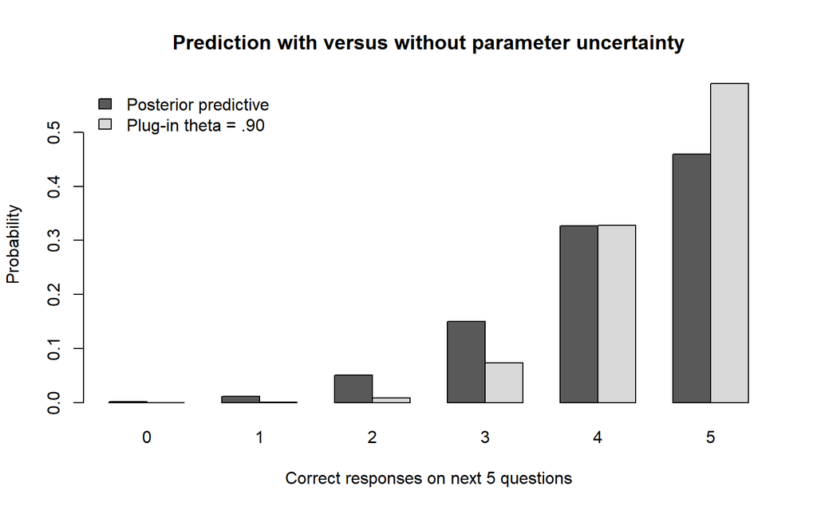

```r
# Rows correspond to the two different predictive distributions.
prediction_matrix <- rbind(
  "Posterior predictive" = as.numeric(posterior_predictive),
  "Plug-in theta=.90" = plugin_predictive
)

# Define the exact fills used by the rows.
# Dark gray = posterior predictive.
# Light gray = plug-in theta=.90.
prediction_fills <- c("gray35", "gray85")

barplot(
  prediction_matrix,
  beside = TRUE,
  col = prediction_fills,
  names.arg = 0:5,
  xlab = "Correct responses on next 5 questions",
  ylab = "Probability",
  main = "Prediction with versus without parameter uncertainty"
)

# `fill` uses the same vector as `barplot(col=...)`, so the legend matches the bars.
legend(
  "topleft",
  legend = c(
    "Posterior predictive",
    "Plug-in theta = .90"
  ),
  fill = prediction_fills,
  bty = "n"
)
```

The dark bars use the **whole posterior distribution** of $\theta$. The light bars behave as if $\theta=.90$ were known without uncertainty.

The posterior predictive is more dispersed because it carries forward two sources of uncertainty:

1. uncertainty about the parameter $\theta$;
2. randomness in future observations even if $\theta$ were known.

# 13 Sequential updating

Suppose a second set of five questions is observed and the person gets 3 correct.

After the first dataset, the posterior was:

$$Beta(10,2)$$

Bayesian updating lets that posterior become the prior for the new data.

```r
# NEW DATA.
new_n <- 5
new_k <- 3

new_successes <- new_k
new_failures <- new_n - new_k

# Previous posterior Beta(10,2) becomes the starting distribution for the new update.
# Add the new successes and failures.
alpha_after_both <- alpha_posterior + new_successes
beta_after_both <- beta_posterior + new_failures

c(
  alpha_after_both = alpha_after_both,
  beta_after_both = beta_after_both
)
```

```
## alpha_after_both  beta_after_both
##               13                4
```

The final posterior is therefore:

$$Beta(13,4)$$

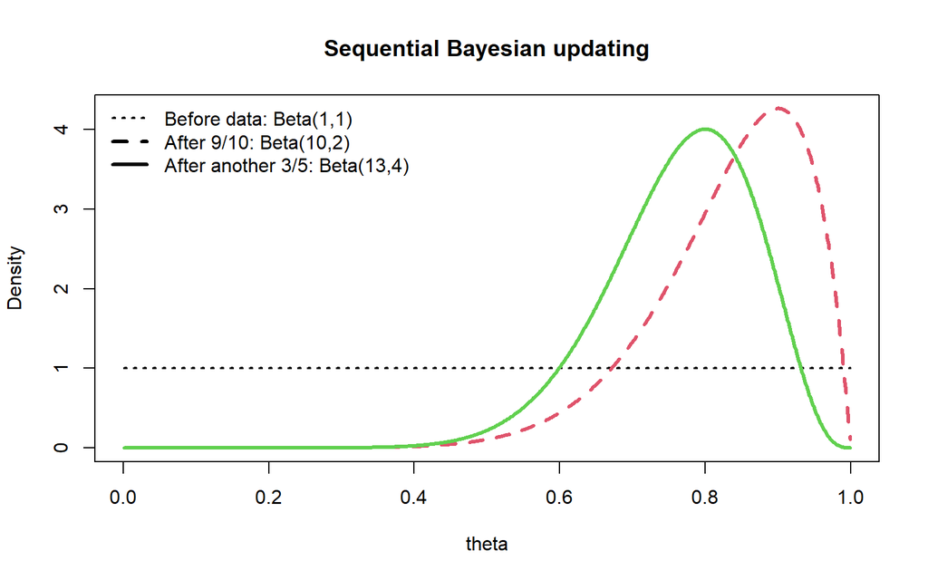

```r
# Densities at the three stages of learning.
prior_initial <- dbeta(theta, 1, 1)
posterior_batch1 <- dbeta(theta, 10, 2)
posterior_batch2 <- dbeta(theta, 13, 4)

matplot(
  theta,
  cbind(prior_initial, posterior_batch1, posterior_batch2),
  type = "l",
  lty = c(3, 2, 1),
  lwd = c(2, 3, 3),
  xlab = "theta",
  ylab = "Density",
  main = "Sequential Bayesian updating"
)

legend(
  "topleft",
  legend = c(
    "Before data: Beta(1,1)",
    "After 9/10: Beta(10,2)",
    "After another 3/5: Beta(13,4)"
  ),
  lty = c(3, 2, 1),
  lwd = c(2, 3, 3),
  bty = "n"
)
```

The second batch is weaker performance than the first, so the posterior shifts downward somewhat.

# 14 Sequential and batch updating agree

The same total information can be summarized as 12 successes and 3 failures.

```r
# Combine the two observed batches.
total_successes <- 9 + 3
total_failures <- 1 + 2

# Update the ORIGINAL Beta(1,1) prior using all data at once.
alpha_batch <- 1 + total_successes
beta_batch <- 1 + total_failures

c(
  alpha_batch = alpha_batch,
  beta_batch = beta_batch
)
```

```
## alpha_batch  beta_batch
##          13           4
```

The result is again $Beta(13,4)$.

```r
# Both comparisons should return TRUE.
c(
  same_alpha = alpha_after_both == alpha_batch,
  same_beta = beta_after_both == beta_batch
)
```

```
## same_alpha  same_beta
##       TRUE       TRUE
```

This is the chapter’s idea that “today’s posterior is tomorrow’s prior”: information can be accumulated sequentially without changing the final posterior when the same model and same data are used.

# 15 Why MCMC is needed

For the Beta-Binomial example, the posterior is easy to derive exactly.

In more realistic cognitive models, the posterior may involve many parameters, latent variables, hierarchical structure, or nonlinear relationships. The posterior can still be conceptually defined by:

$$p(\theta\mid D) \propto p(D\mid\theta)p(\theta)$$

but may no longer be easy to calculate analytically.

This is where MCMC enters.

Keep three levels distinct:

```
SCIENTIFIC MODEL:
what hidden parameters exist and how they generate observable data

BAYESIAN INFERENCE:
prior + likelihood -> posterior

MCMC:
a computational method for approximating a difficult posterior
```

MCMC is not the model.

# 16 Posterior draws before MCMC

Because our posterior is a known Beta distribution, we can draw from it directly.

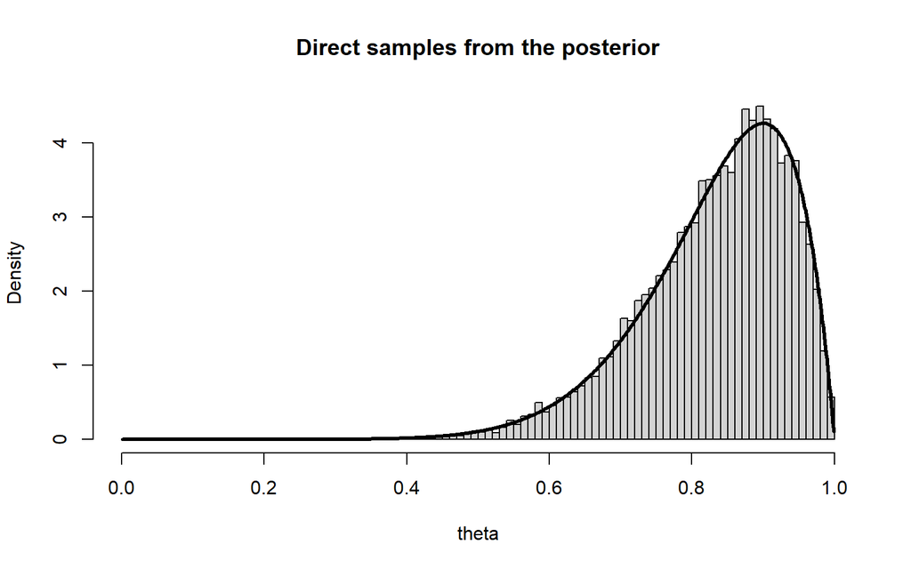

```r
# Draw 10,000 independent theta values directly from the known Beta(10,2) posterior.
# This is NOT MCMC; direct sampling is possible because the posterior is analytically simple.
direct_draws <- rbeta(
  n = 10000,
  shape1 = alpha_posterior,
  shape2 = beta_posterior
)

hist(
  direct_draws,
  breaks = 50,
  freq = FALSE,
  xlim = c(0, 1),
  xlab = "theta",
  main = "Direct samples from the posterior"
)

# Overlay the exact posterior density.
lines(theta, posterior, lwd = 3)
```

This introduces the key computational idea:

> A posterior distribution can be represented by a sufficiently large collection of draws from that distribution.

MCMC is useful when we cannot obtain those draws directly.

# 17 A simple Metropolis sampler

The code below is a teaching implementation of a random-walk Metropolis sampler. It is included to make the MCMC logic visible; it is not intended as production Bayesian software.

First define the posterior target that the sampler needs to evaluate.

```r
# Given ONE candidate theta, return its relative LOG posterior support.
log_posterior <- function(theta) {

  # theta is a probability. Values outside (0,1) are impossible under the model.
  if (theta <= 0 || theta >= 1) {
    return(-Inf)
  }

  # PRIOR contribution: log p(theta).
  # log=TRUE asks dbeta() for log density rather than ordinary density.
  log_prior <- dbeta(
    x = theta,
    shape1 = 1,
    shape2 = 1,
    log = TRUE
  )

  # LIKELIHOOD contribution: log p(observed 9/10 | theta).
  # The data stay fixed; this function is called repeatedly at different candidate theta values.
  log_likelihood <- dbinom(
    x = k,
    size = n,
    prob = theta,
    log = TRUE
  )

  # On the log scale, multiplying prior × likelihood becomes addition.
  # The normalizing constant is not needed because Metropolis compares relative support.
  log_prior + log_likelihood
}
```

Now define the transition rule.

```r
run_chain <- function(
  start,
  iterations = 10000,
  proposal_sd = 0.08
) {

  # Store the theta values visited by the chain.
  chain <- numeric(iterations)
  chain[1] <- start

  for (i in 2:iterations) {

    # Current parameter value.
    current <- chain[i - 1]

    # Propose a nearby parameter value.
    # rnorm() is only the proposal mechanism; this Normal distribution is
    # neither the prior nor the posterior.
    proposed <- rnorm(
      n = 1,
      mean = current,
      sd = proposal_sd
    )

    # Compare log posterior support of proposed versus current theta.
    log_ratio <-
      log_posterior(proposed) -
      log_posterior(current)

    # Metropolis acceptance rule.
    #
    # If proposed has higher posterior support, log_ratio > 0 and it is accepted.
    # If it has lower support, it can still be accepted with probability exp(log_ratio).
    # Occasional downhill moves prevent the algorithm from behaving like simple optimization.
    if (log(runif(1)) < log_ratio) {
      chain[i] <- proposed
    } else {
      chain[i] <- current
    }
  }

  chain
}
```

Run several chains from different starting values.

```r
chain1 <- run_chain(start = 0.10)
chain2 <- run_chain(start = 0.50)
chain3 <- run_chain(start = 0.95)
```

The different starts are deliberate. If the sampler converges, the chains should eventually forget those arbitrary starting points and explore the same posterior region.

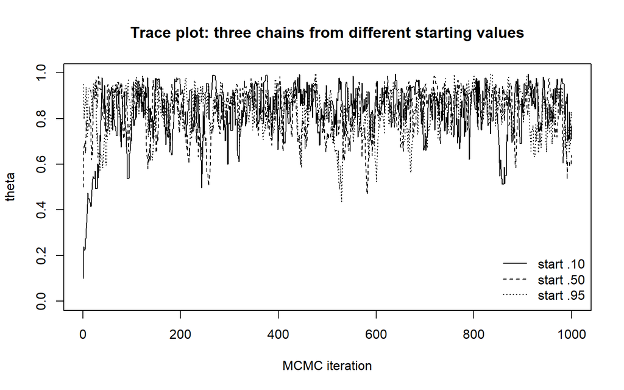

```r
# Show the early part so the different starting values are visible.
plot(
  chain1[1:1000],
  type = "l",
  ylim = c(0, 1),
  xlab = "MCMC iteration",
  ylab = "theta",
  main = "Trace plot: three chains from different starting values"
)
lines(chain2[1:1000], lty = 2)
lines(chain3[1:1000], lty = 3)

legend(
  "bottomright",
  legend = c("start .10", "start .50", "start .95"),
  lty = c(1, 2, 3),
  bty = "n"
)
```

The diagnostic question is:

> Do the chains stop reflecting their starting points and begin exploring the same stable region?

# 18 Warm-up, posterior approximation, and autocorrelation

For this teaching example, discard an initial portion of each chain before summarizing the posterior.

```r
# Teaching choice for this simple sampler.
warmup <- 2000

post_chain1 <- chain1[(warmup + 1):length(chain1)]
post_chain2 <- chain2[(warmup + 1):length(chain2)]
post_chain3 <- chain3[(warmup + 1):length(chain3)]

# Pool the retained states from the three chains.
mcmc_draws <- c(post_chain1, post_chain2, post_chain3)
```

Compare the MCMC approximation with the exact posterior, which we happen to know for this toy problem.

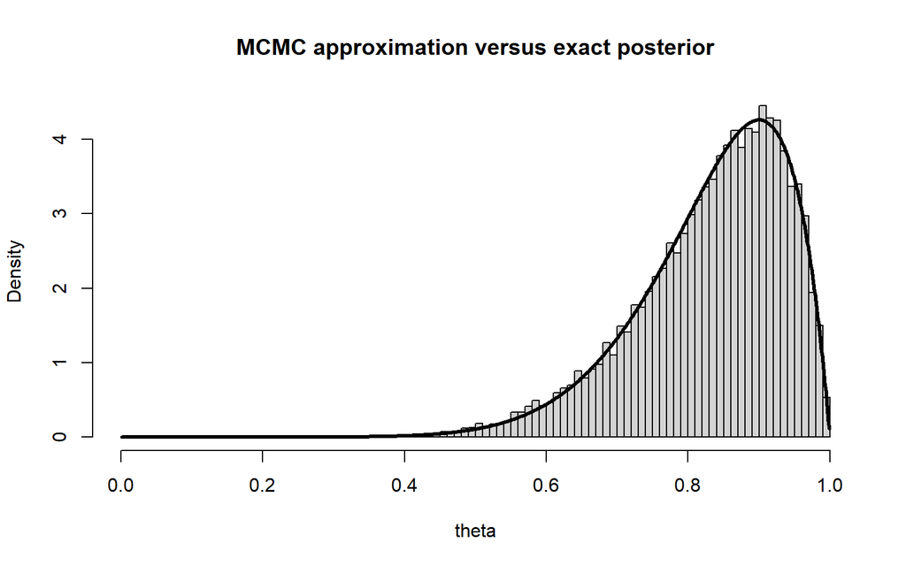

```r
hist(
  mcmc_draws,
  breaks = 50,
  freq = FALSE,
  xlim = c(0, 1),
  xlab = "theta",
  main = "MCMC approximation versus exact posterior"
)

lines(theta, posterior, lwd = 3)
```

Now summarize the posterior from the samples alone.

```r
# These summaries use the empirical MCMC draws rather than the exact Beta formula.
c(
  mean = mean(mcmc_draws),
  median = median(mcmc_draws),
  lower_95 = unname(quantile(mcmc_draws, probs = 0.025)),
  upper_95 = unname(quantile(mcmc_draws, probs = 0.975))
)
```

```
##      mean    median  lower_95  upper_95
## 0.8319536 0.8516354 0.5772895 0.9774050
```

Notice the function distinction:

- `qbeta(p=...)` was used when we knew the posterior was a Beta distribution;
- `quantile(probs=...)` is used here directly on empirical posterior draws.

Finally, inspect dependence between consecutive MCMC samples.

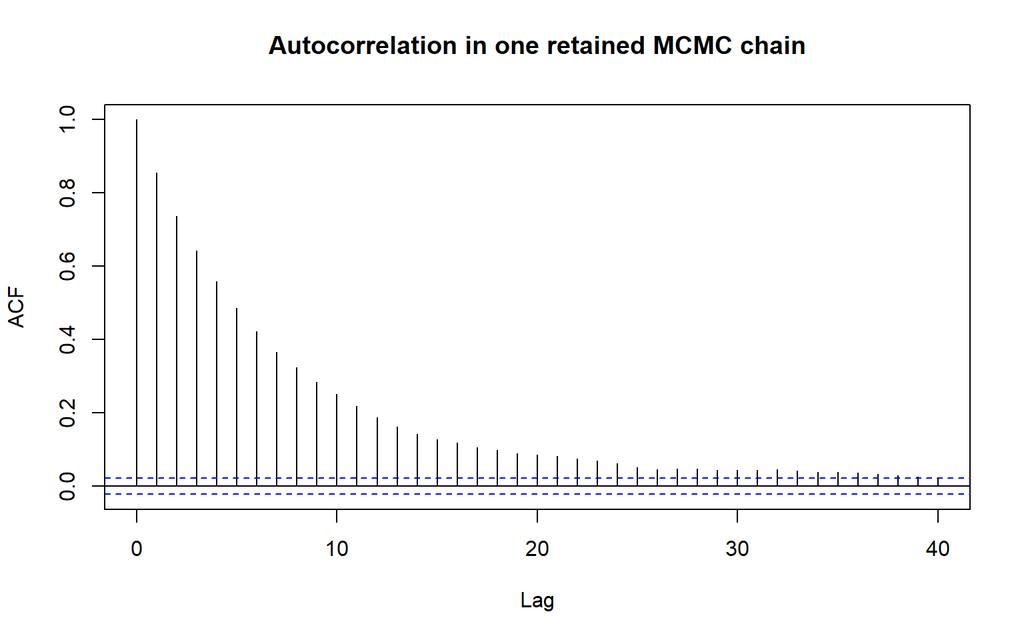

```r
# acf() shows how strongly chain values are related across different iteration lags.
# Strong positive autocorrelation means successive draws contain partly redundant information.
acf(
  post_chain1,
  lag.max = 40,
  main = "Autocorrelation in one retained MCMC chain"
)
```

This is why 10,000 MCMC draws do not necessarily contain the same amount of information as 10,000 independent draws.

# 19 What the simple model is assuming

The Bayesian calculations can be perfectly correct while the scientific model is inappropriate.

Our binomial model assumes, among other things:

1. one stable $\theta$ across all questions;
2. binary outcomes;
3. conditional independence;
4. no learning, fatigue, or order effects;
5. no item-specific differences in difficulty.

If those assumptions are poor descriptions of the real process, the posterior is still a posterior — but it is a posterior under a poor model.

> **Bayesian inference quantifies uncertainty conditional on the model. It does not guarantee that the model is scientifically adequate.**

# 20 Connection to cognitive modelling

The binomial example is simple, but the architecture generalizes directly.

Here:

```
theta
  ↓
binomial sampling model
  ↓
number correct
```

In an evidence-accumulation model, the hidden parameters might instead include quantities such as:

```
drift rate v
threshold a
non-decision time t0
        ↓
evidence-accumulation model
        ↓
choice + response time
```

The Bayesian structure remains:

```
PRIORS on hidden parameters
            +
LIKELIHOOD: how those parameters generate observable behaviour
            +
OBSERVED DATA
            =
POSTERIOR over the hidden parameters
```

MCMC or another computational method becomes necessary when that posterior cannot be obtained directly.

# 21 Chapter 1 in one workflow

```
1. Observe data
   9 correct out of 10

2. Define the unknown parameter
   theta = underlying success probability

3. Specify how the parameter generates data
   K ~ Binomial(n, theta)

4. Specify prior uncertainty
   theta ~ Beta(1,1)

5. Evaluate the observed data across candidate parameter values
   likelihood = p(data | theta)

6. Combine likelihood with prior
   posterior ∝ likelihood × prior

7. Interpret posterior uncertainty
   p(theta | data)

8. Carry that uncertainty into predictions
   p(new data | observed data)

9. If the posterior is hard to calculate
   approximate it computationally, e.g. with MCMC
```

The central idea is:

> **Specify how hidden quantities could generate data, observe the data, and use those observations to revise uncertainty about the hidden quantities.**